# Baseline vs Best 100K Model Comparison

**Models compared:**

- **Baseline**: Moirai2 Small, 100K steps, no preconditioning (MASE 1.2878)
- **Best 100K**: Moirai2 Small + Chebyshev d=4 hint + 10% hint dropout, 100K steps (MASE 1.1918)

**Checkpoints:**

```
Baseline:  /scratch/gpfs/EHAZAN/jh1161/uni2ts/outputs/pretrain/moirai2_small/lotsa_v1_unweighted/m2_baseline_20260209_114203/checkpoints/epoch_999-step_100000.ckpt
Best 100K: /scratch/gpfs/EHAZAN/jh1161/uni2ts/outputs/pretrain/moirai2_small/lotsa_v1_unweighted/m2_hd10_100k_20260223_112829/checkpoints/epoch_999-step_100000.ckpt
```

**Evaluation settings** (identical for both): context_length=4000, patch_size=32, batch_size=64, 97 GIFT-Eval configs.

**Training note:** Baseline uses 10K warmup steps; hint model uses 1K warmup steps. Both use cosine annealing, AdamW (lr=1e-3), 100K total steps (1000 epochs x 100 batches, bs=256) on LOTSA v1.

**Data files** (all in this folder):

- `baseline_100k_eval.csv` — GIFT-Eval results for baseline (from `gifteval/results/gifteval_results_epoch_999-step_100000_20260210_203632.csv`)
- `hd10_100k_eval.csv` — GIFT-Eval results for hint+dropout model (from `gifteval/results/gifteval_results_epoch_999-step_100000_20260223_235237.csv`)
- `training_loss_data.json` — Training loss curves extracted from TensorBoard event files

```
Baseline eval: 97 configs (context=4000, patch=32)
HD10 eval:     97 configs (context=4000, patch=32)

Baseline geo mean MASE: 1.2878
HD10 geo mean MASE:     1.1918
```

## 1. Architecture Comparison

### Baseline: Standard Moirai2 Small

The baseline is a **causal decoder-only transformer** for time series forecasting:

| Component | Details |
| --- | --- |
| **d_model** | 384 |
| **d_ff** | 1024 |
| **Layers** | 6 attention layers |
| **Patch size** | 16 (each patch = 16 time steps) |
| **Parameters** | 11.39M |
| **Loss** | PackedQuantileMAELoss (pinball loss over 9 quantiles) |
| **Scaler** | Per-series z-score normalization |

**Input representation per patch**: `[target (16), observation_mask (16)]` = 32 dims, projected to 384 via `in_proj`.

### Best 100K: Moirai2 Small + Preconditioning Hint

The hint model adds **one extra input channel** per patch containing the preconditioning filter residual:

| Component | Details |
| --- | --- |
| **Architecture** | Same 6-layer causal transformer |
| **Parameters** | 11.40M (+12K for wider `in_proj`: 48 -> 384 instead of 32 -> 384) |
| **Hint channel** | Chebyshev degree-4 preconditioning filter residual at stride 16 |
| **Hint dropout** | 10% (per-patch, training only) |

**Input representation per patch**: `[target (16), observation_mask (16), hint_d4 (16)]` = 48 dims, projected to 384.

The hint channel computes a **causal preconditioning filter residual** (technically a Finite Impulse Response / FIR filter):

```
hint[t] = -1.0 * y[t-16] + 0.125 * y[t-48]
```

This tells the model "how does this time step relate to the same position in previous patches" -- providing explicit inter-patch autocorrelation information. The hint is zeroed in the prediction window (future values unknown).

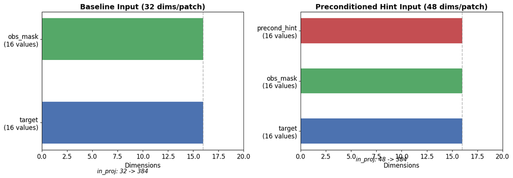

## 2. Training Loss Comparison

Both models are trained for 100K steps (1000 epochs x 100 batches/epoch, batch_size=256) on LOTSA v1.

The training loss is `PackedQuantileMAELoss` -- pinball loss over 9 quantile levels (0.1 to 0.9). This is the same loss function for both models; the only difference is what inputs the model receives.

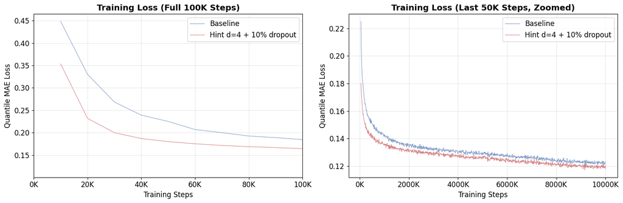

```
Baseline:  first epoch loss = 0.4482, final epoch loss = 0.1233
Hint d=4:  first epoch loss = 0.3534, final epoch loss = 0.1204

Delta at final epoch: -0.0029 (-2.4%)
```

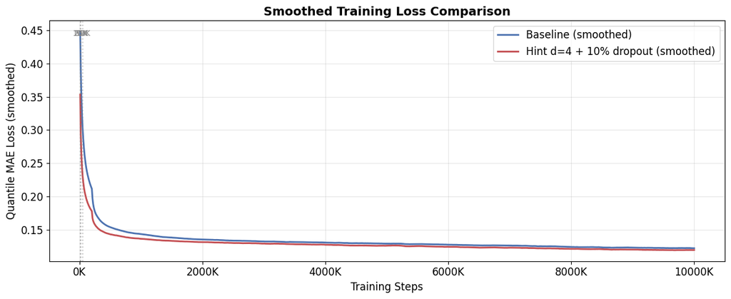

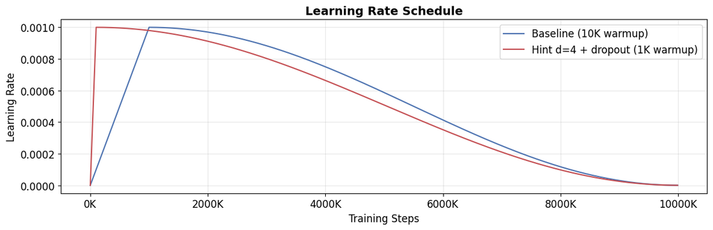

```
Note: Baseline uses 10K warmup steps, hint model uses 1K warmup steps.
Both use cosine annealing after warmup.
```

## 3. GIFT-Eval Results Comparison

GIFT-Eval is a comprehensive time series forecasting benchmark with 97 configurations across multiple datasets, frequencies (from 10-second to yearly), and forecast horizons (short/medium/long).

**Primary metric**: MASE (Mean Absolute Scaled Error). MASE < 1.0 means the model beats the seasonal naive baseline.

```
============================================================
GIFT-Eval Summary (97 configurations)
============================================================
Metric                                Baseline  Hint+Drop
------------------------------------------------------------
Geo Mean MASE                           1.2878     1.1918
Arith Mean MASE                         2.0066     1.9061
Median MASE                             1.1546     1.0470
Configs < 1.0 MASE (beat naive)             34         42
Min MASE                                0.2847     0.2876
Max MASE                               48.8027    46.9033
------------------------------------------------------------
Hint wins / losses                    81 /   16
Relative improvement (geo mean)          7.46%
```

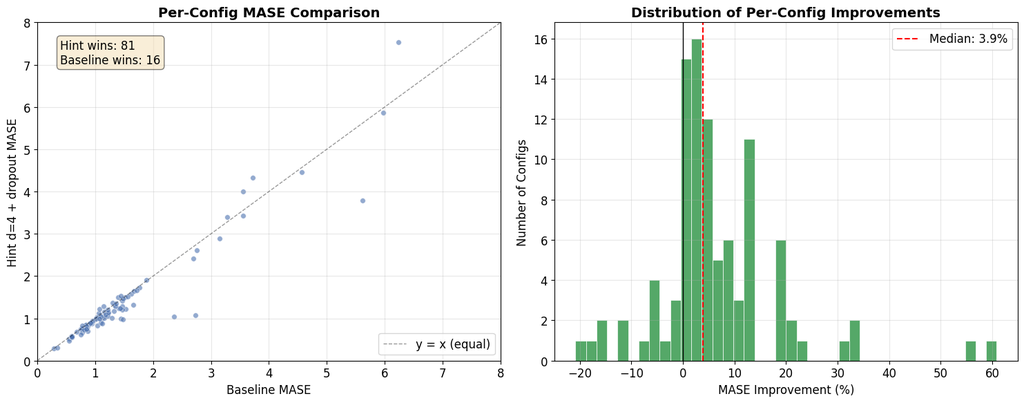

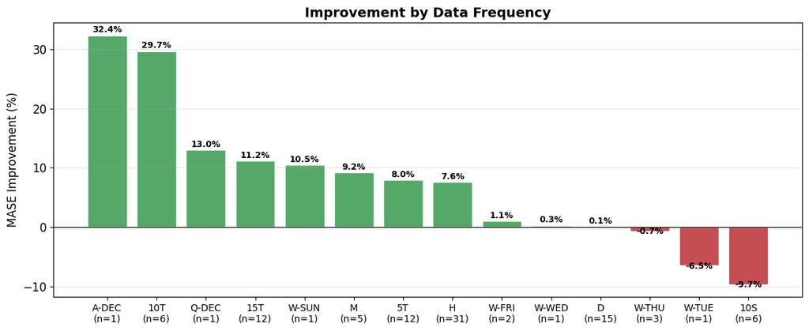

```
Frequency  N  Geo MASE (Baseline)  Geo MASE (Hint+Drop)  Improvement (%)  Wins  Losses
    A-DEC  1                 5.61                  3.79            32.39     1       0
      10T  6                 1.08                  0.76            29.72     5       1
    Q-DEC  1                 1.43                  1.24            13.03     1       0
      15T 12                 1.04                  0.92            11.19    12       0
    W-SUN  1                 2.69                  2.41            10.47     1       0
        M  5                 0.87                  0.79             9.19     5       0
       5T 12                 1.18                  1.08             7.95    11       1
        H 31                 1.09                  1.00             7.62    29       2
    W-FRI  2                 1.80                  1.78             1.06     1       1
    W-WED  1                 0.75                  0.75             0.29     1       0
        D 15                 1.57                  1.57             0.09    10       5
    W-THU  3                 1.35                  1.36            -0.67     2       1
    W-TUE  1                 1.44                  1.53            -6.51     0       1
      10S  6                 3.70                  4.05            -9.68     2       4
```

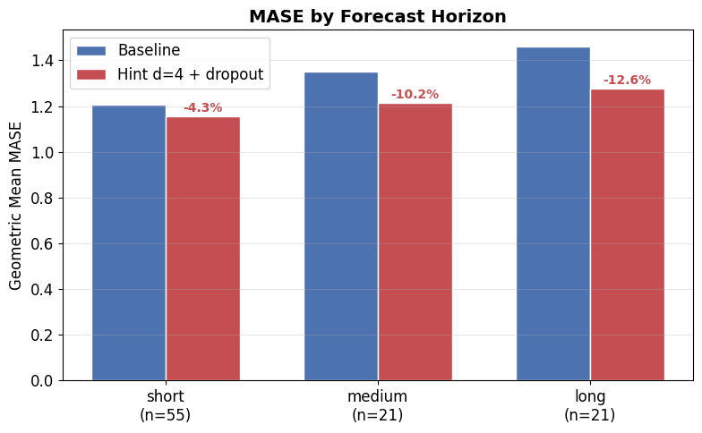

```
Horizon  N  Geo MASE (Baseline)  Geo MASE (Hint+Drop)  Improvement (%)  Wins  Losses
  short 55                 1.21                  1.15             4.29    45      10
 medium 21                 1.35                  1.21            10.24    18       3
   long 21                 1.46                  1.28            12.64    18       3
```

```
================================================================================
TOP 15 BIGGEST IMPROVEMENTS (Hint+Dropout over Baseline)
================================================================================
                     Config  Baseline MASE  Hint+Drop MASE  Improvement (%)
         solar/10T/10T/long         2.7314          1.0687          60.8735
       solar/10T/10T/medium         2.3618          1.0343          56.2089
      LOOP_SEATTLE/H/H/long         1.4762          0.9735          34.0553
      m4_yearly/A-DEC/short         5.6111          3.7938          32.3877
    LOOP_SEATTLE/H/H/medium         1.4475          1.0002          30.9024
          m4_hourly/H/short         1.2884          1.0041          22.0610
   electricity/15T/15T/long         1.6618          1.3128          21.0011
     LOOP_SEATTLE/H/H/short         1.1180          0.8847          20.8722
  LOOP_SEATTLE/5T/5T/medium         1.0404          0.8324          19.9887
 electricity/15T/15T/medium         1.5273          1.2263          19.7096
        us_births/M/M/short         0.7546          0.6093          19.2620
    LOOP_SEATTLE/5T/5T/long         1.0954          0.8864          19.0806
  jena_weather/10T/10T/long         0.8661          0.7039          18.7316
          ett1/15T/15T/long         1.4653          1.1998          18.1193
jena_weather/10T/10T/medium         0.7776          0.6697          13.8711

================================================================================
TOP 10 WORST REGRESSIONS
================================================================================
                         Config  Baseline MASE  Hint+Drop MASE  Improvement (%)
bizitobs_application/10S/medium         6.2308          7.5306         -20.8615
  bizitobs_application/10S/long         6.9302          8.2103         -18.4706
      bizitobs_service/10S/long         3.7177          4.3347         -16.5966
            solar/10T/10T/short         1.0680          1.2260         -14.7934
    bizitobs_service/10S/medium         3.5569          4.0017         -12.5049
                solar/D/D/short         1.1510          1.2825         -11.4249
                 ett2/D/D/short         1.3935          1.5048          -7.9854
        us_births/W/W-TUE/short         1.4403          1.5340          -6.5095
             ett2/W/W-THU/short         1.0643          1.1291          -6.0938
              M_DENSE/D/D/short         0.7764          0.8214          -5.8004
```

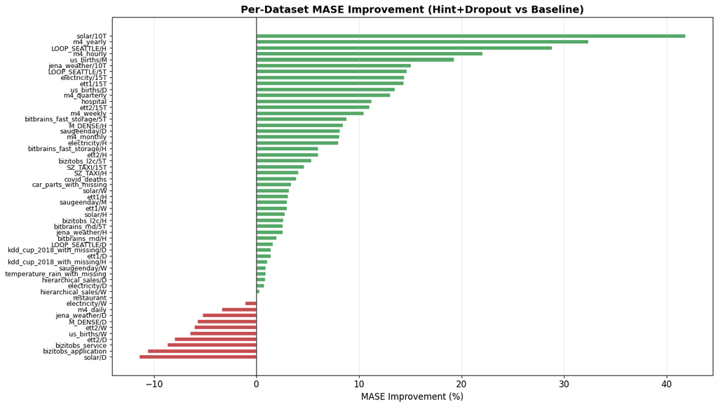

### 3.1 Where Do Hints Help Most?

To understand *why* hints help, we categorize datasets by domain and analyze patterns in the improvements.

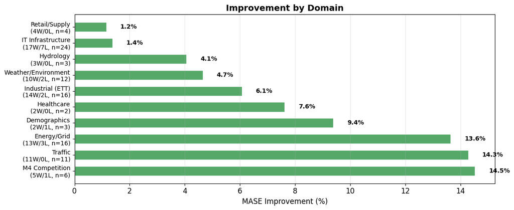

```
             Domain  N  Datasets  Geo MASE (Baseline)  Geo MASE (Hint)  Improvement (%)
     M4 Competition  6         6                2.148            1.836           14.527
            Traffic 11         5                0.858            0.735           14.287
        Energy/Grid 16         8                1.397            1.207           13.647
       Demographics  3         3                0.841            0.762            9.393
         Healthcare  2         2                6.474            5.981            7.619
   Industrial (ETT) 16         8                1.189            1.117            6.070
Weather/Environment 12         6                0.892            0.850            4.656
          Hydrology  3         3                1.539            1.477            4.061
  IT Infrastructure 24        10                1.612            1.589            1.377
      Retail/Supply  4         4                0.764            0.755            1.158
```

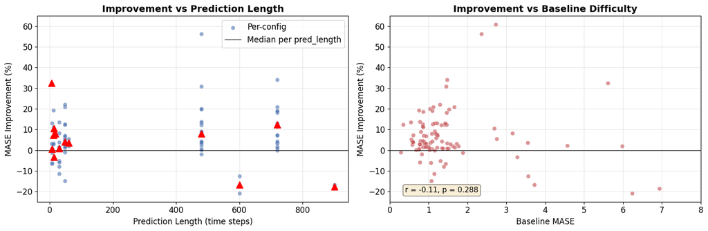

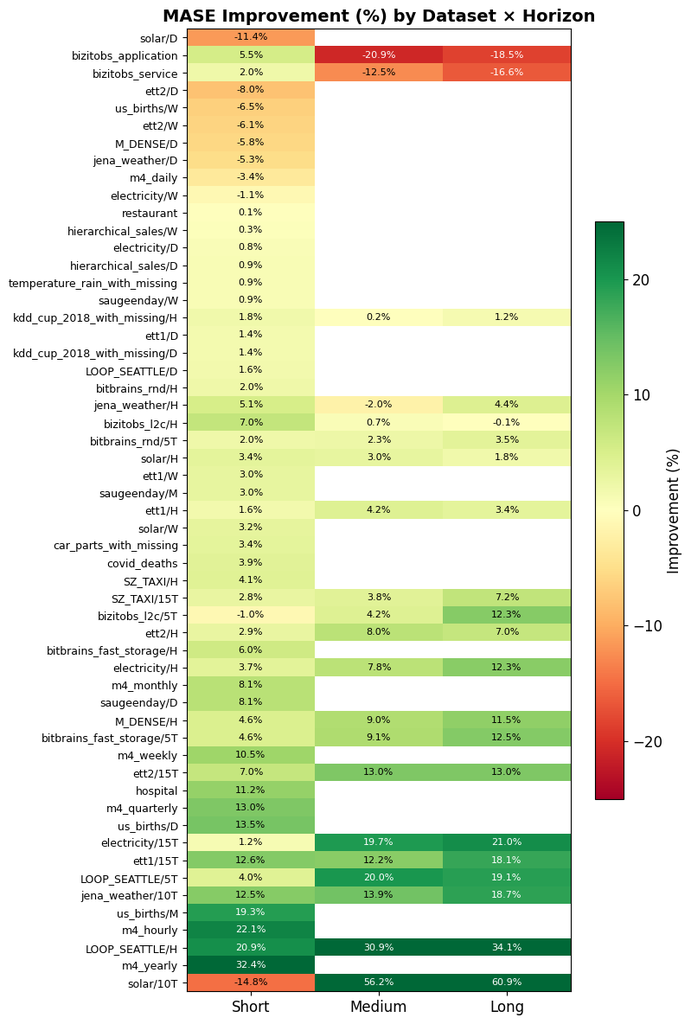

### 3.2 Analysis: Where and Why Preconditioning Hints Help

**Strong improvements (>10%):**

- **Energy/solar at sub-hourly frequency**: Solar 10T medium/long see 56-61% improvement — the largest gains in the benchmark. Solar energy has strong diurnal periodicity at exactly the patch-boundary scale, which the preconditioning filter directly encodes.
- **Traffic (LOOP_SEATTLE)**: 19-34% improvement. Traffic has strong daily/weekly periodicity. The hint at stride=16 captures the repeating pattern across patches.
- **Electricity sub-hourly**: 19-21% improvement at 15T medium/long. Similar periodic structure.
- **ETT sub-hourly**: 13-18% improvement at 15T long. Industrial transformer data has temporal regularity.

**Regressions (<0%):**

- **bizitobs (application/service) at 10S**: -15% to -21%. These are the most fine-grained series (10-second intervals). The preconditioning filter at stride=16 looks back 160 seconds and 480 seconds — these may not be meaningful timescales for application monitoring, where patterns are more bursty than periodic.
- **solar/D short, solar/10T short**: -11% to -15%. Interestingly, solar *short* horizon hurts while medium/long helps massively. At short horizons, the model may not need inter-patch structure — the immediate context is sufficient.
- **Weekly/daily data (ett2/W, us_births/W, M_DENSE/D)**: -5% to -8%. Lower-frequency data has fewer patches in the context window, so the preconditioning filter has less material to work with.

**Key insight**: Preconditioning hints help most when **(a)** the data has strong inter-patch autocorrelation at the stride-16 timescale, and **(b)** the prediction horizon is long enough that the model benefits from explicit structural information. Short-horizon predictions on irregular/bursty data see the least benefit.

## 4. How Hint Dropout Works

Hint dropout is a regularization technique applied **only during training** that randomly zeros out entire hint channels for individual patches. Here's how it works:

### Mechanism

During each training forward pass:

1. The hint channel `hint_d4[t]` is computed for every patch
2. For each patch independently, a random number is drawn from Uniform(0, 1)
3. If that number < 0.1 (the 10% dropout rate), the **entire** hint vector for that patch is set to zero
4. The remaining 90% of patches keep their full hint information

```
# From module.py — the actual implementation:
if training_mode and self.hint_dropout > 0:
    for i in range(len(hint_channels)):
        hint_mask = torch.rand(
            hint_channels[i].shape[:-1], device=hint_channels[i].device
        ) < self.hint_dropout
        hint_channels[i] = hint_channels[i].masked_fill(hint_mask.unsqueeze(-1), 0.0)
```

### Key design choices:

- **Per-patch, not per-element**: The entire 16-dimensional hint vector for a patch is either kept or zeroed. This is analogous to spatial dropout in CNNs — it forces the model to not rely on any single patch's hint.
- **Training only**: At inference, all hints are always present (no dropout).
- **Independent per patch**: Each patch in the sequence independently decides whether to drop its hint.

### Why it matters at 100K steps

| Training | Without dropout | With 10% dropout |
| --- | --- | --- |
| 10K steps | MASE 1.1944 | MASE 1.1802 (-1.2%) |
| **100K steps** | **MASE 1.2135** | **MASE 1.1918 (-1.8%)** |
| vs 100K baseline | -5.77% | **-7.45%** |

At short training (10K), hints already act as a regularizer — the model hasn't memorized the training data yet, so adding dropout is only marginally helpful.

At long training (100K), the baseline **overfits** (MASE degrades from 1.2421 at 10K to 1.2878 at 100K). Without dropout, the hint model also partially overfits by learning to rely too heavily on the hint signal. With 10% dropout, the model is forced to sometimes make predictions without hints, which:

1. Prevents over-reliance on the hint channel
2. Encourages the model to learn both hint-based and hint-free prediction strategies
3. Acts as an ensemble effect — at inference, the full hint is always available, giving the model strictly more information than it had during any single training step

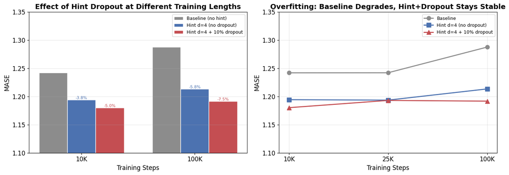

## 5. Inference Pipeline Comparison

### Baseline Pipeline

```
Raw series --> z-score normalize --> [target, mask] --> in_proj (32->384) --> 6-layer causal transformer --> out_proj --> quantile predictions
```

### Preconditioning Hint Model Pipeline

```
Raw series --> z-score normalize --> compute preconditioning hint (causal, backward-looking only)
                                          |
                                          v
                                 [target, mask, hint_d4] --> in_proj (48->384) --> 6-layer causal transformer --> out_proj --> quantile predictions
                                          ^
                                  hint is ZEROED in prediction window
                                  (future values unknown)
```

### What the preconditioning hint provides

The Chebyshev degree-4 preconditioning filter with stride=16 (= patch_size) computes:

```
hint[t] = -1.0 * y[t-16] + 0.125 * y[t-48]
```

This is the **residual** of applying a causal preconditioning filter -- it captures inter-patch autocorrelation at exactly the patch boundary. Because stride=16 matches the patch size, each coefficient connects corresponding positions across patches:

- `y[t-16]`: same position, 1 patch back
- `y[t-48]`: same position, 3 patches back

The transformer's attention already models patch-to-patch relationships, but it must discover these patterns from raw data. The hint **explicitly encodes** this structure, providing an inductive bias that the model can learn to use or ignore.

### Why hint mode works (but reversal doesn't)

- **Reversal mode**: Predict in preconditioned space, then analytically undo the filter. Any prediction error gets amplified through the inverse -- errors compound across patches.
- **Hint mode**: Predictions stay in original z-scored space. The hint is just extra information. The model predicts exactly the same target as baseline, with strictly more input information.

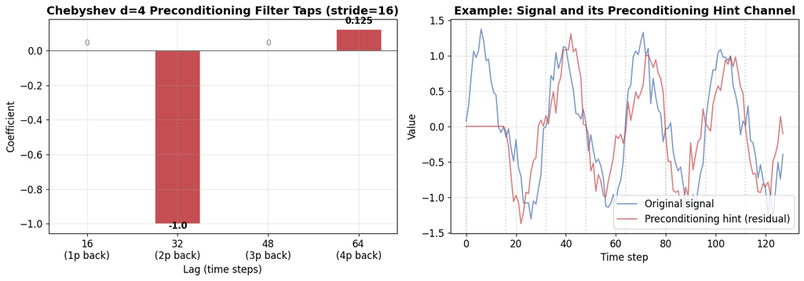

### Autoregressive Generation and Hints

Moirai2 generates forecasts **autoregressively**: it predicts `num_predict_token = 4` patches at a time, then feeds those predictions back as "observed" context for the next forward pass. This repeats until the full prediction horizon is filled.

**Key question**: Are hints recomputed from predicted values during autoregressive generation?

**No.** The hint channels for all prediction-window patches are **zeroed at the start** and never updated. Specifically:

1. Before generation begins, `expand_target` is prepared with context values filled in and prediction slots empty
2. The hint is computed from the context window only — prediction-window positions are zeroed via `h.masked_fill(input_mask.unsqueeze(-1), 0.0)` (see `module.py`)
3. During the autoregressive loop (`forecast.py:374-429`), predicted quantile values are written back into `expand_target` at the next patch positions, and the prediction mask is updated
4. But the hint channels for those newly-filled patches remain zero — they are never recomputed from predictions

```
Step 1:  [ctx_1, ctx_2, ..., ctx_N, ???, ???, ???, ???]   ← context filled, prediction empty
         [h_1,   h_2,   ..., h_N,   0,   0,   0,   0]   ← hints: context computed, prediction zeroed

Step 2:  [ctx_1, ctx_2, ..., ctx_N, p_1, p_2, p_3, p_4, ???, ???, ???, ???]
         [h_1,   h_2,   ..., h_N,   0,   0,   0,   0,   0,   0,   0,   0]  ← still zeroed!

Step 3:  [ctx_1, ctx_2, ..., ctx_N, p_1, p_2, ..., p_8, ???, ???, ???, ???]
         [h_1,   h_2,   ..., h_N,   0,   0,   ..., 0,   0,   0,   0,   0]  ← still zeroed
```

This is consistent with training, where hint dropout (10%) forces the model to sometimes predict without hints. The model learns a dual strategy: use hints when available (context), predict without them when not (prediction window).

## 6. Summary

### Key takeaways

1. **The preconditioning hint model achieves -7.45% lower MASE vs baseline at 100K steps** (1.1918 vs 1.2878), with only +12K extra parameters (+0.1%).
2. **The baseline overfits at 100K** (MASE degrades from 1.2421 at 10K to 1.2878 at 100K). The hint+dropout model does not — it maintains MASE 1.1918, even better than the 10K baseline.
3. **Hint dropout is critical at long training**. Without it, hint d=4 at 100K gives -5.77%; with 10% dropout it gives -7.45%. The dropout prevents the model from over-relying on the hint signal.
4. **Improvements are concentrated in periodic, sub-hourly data at long horizons**. Solar, traffic, electricity, and ETT datasets at 5T/10T/15T/H frequencies see 10-61% improvement. The preconditioning filter at stride=16 directly encodes inter-patch autocorrelation that matches the natural periodicity of these domains.
5. **Regressions occur on bursty/irregular data and short horizons**. IT monitoring data at 10S frequency (-15% to -21%) and short-horizon predictions on low-frequency data (-5% to -8%) see degradation. The stride-16 preconditioning filter taps don't align with meaningful timescales for these series.
6. **Hints are context-only during autoregressive generation**. The model generates 4 patches per step, feeds predictions back, but hint channels remain zeroed for all prediction patches. Hint dropout during training prepares the model for this.
7. **The architecture change is minimal**: same transformer, same loss, same everything except `in_proj` goes from 32 to 48 dims to accommodate the hint channel.

## 7. Lessons Learned from 50+ Experiments

The following lessons are distilled from over 50 preconditioning experiments across 4 polynomial families, 7 degrees, 5 dropout rates, multiple strides, and several architectural variants. All MASE numbers are geometric means across 97 GIFT-Eval configurations.

### Lesson 1: Reversal Fails — Hint Mode Is the Only Way

Standard preconditioning (filter the input, train, analytically reverse at inference) **does not work** for multi-step forecasting. Forecast errors compound through the inverse filter:

| Approach | Best MASE | vs Baseline |
| --- | --- | --- |
| Reversal d=2 s=16 | 1.2227 | -1.56% |
| Reversal d=4 s=16 | 1.2487 | +0.53% |
| First differencing (coeff -1.0) | 1.5926 | +28.2% |
| Dual-head (raw + precond outputs) | 1.5576 | +25.3% |
| **Hint d=4 s=16** | **1.1944** | **-3.84%** |
| **Hint d=6 s=16** | **1.1836** | **-4.71%** |

The fundamental issue: any prediction error in preconditioned space gets amplified when reversing. Higher-degree polynomials make this worse (d=4 reversal is already worse than baseline). Hint mode avoids reversal entirely — the model predicts in raw z-scored space with the filter residual as extra information.

### Lesson 2: Stride Must Match Patch Size

The preconditioning filter stride must equal the patch size (16) so that filter taps connect corresponding positions across patches, aligning with how the transformer's attention processes temporal information:

| Stride | Context | MASE | Note |
| --- | --- | --- | --- |
| s=1 | Intra-patch correlations | ~1.59 | Catastrophic failure |
| s=4 | hint d=6 s=4 | 1.2346 | -0.60% — mediocre |
| s=8 | Multi-stride d=4 s=16+s=8 | 1.2057 | -2.93% |
| **s=16** | **Inter-patch, patch-aligned** | **1.1836** | **-4.71% (d=6)** |

Stride=1 creates intra-patch correlations that confuse the patch embedding. Stride=16 ensures each filter tap references the same position in a previous patch, which is semantically meaningful for the transformer.

### Lesson 3: Multi-Scale d=4+d=6 Is Uniquely Optimal

Adding a second hint channel at a different polynomial degree captures complementary spectral information. But the specific combination d=4+d=6 is a sharp optimum:

| Multi-Scale Config | MASE | vs Baseline |
| --- | --- | --- |
| **d=4 + d=6** | **1.1675** | **-6.01%** |
| d=4 + d=2 + d=6 (triple) | 1.1940 | -3.87% |
| d=4 + d=5 | 1.2225 | -1.58% |
| d=4 + d=8 | 1.2135 | -2.30% |
| d=4 + d=6 + d=8 (triple) | 1.2257 | -1.32% |
| d=6 + d=8 (no d=4) | 1.2287 | -1.08% |

d=4 and d=6 capture complementary frequency bands — d=4 provides moderate smoothing (max|c|=1.0) while d=6 captures higher-order spectral detail (max|c|=1.5). Adding d=5 is redundant (too similar to d=4), d=8 is too aggressive, and triple combinations add noise.

### Lesson 4: Primary Degree Ordering Matters

In multi-scale configurations, the first hint channel gets preferential treatment from the input projection. Swapping d=4 and d=6 as primary/secondary is catastrophic:

| Config | MASE | vs Baseline |
| --- | --- | --- |
| **d=4 primary + d=6 extra** | **1.1675** | **-6.01%** |
| d=6 primary + d=4 extra | 1.2365 | -0.45% |

**Swapping costs 5.6% in MASE.** d=4 is the anchor degree for multi-scale hints.

### Lesson 5: Degree Sweep Is Non-Monotonic

The relationship between polynomial degree and performance is not monotonic — there are two local optima at d=4 and d=6:

| Degree | Chebyshev Coefficients (non-zero) | MASE | vs Baseline |
| --- | --- | --- | --- |
| d=2 | `c₁=-0.5` | 1.2157 | -2.13% |
| d=3 | `c₁=-0.75` | 1.2040 | -3.07% |
| **d=4** | **`c₁=-1.0, c₃=0.125`** | **1.1944** | **-3.84%** |
| d=5 | `c₁=-1.25, c₃=0.3125` | 1.2084 | -2.71% |
| **d=6** | **`c₁=-1.5, c₃=0.5625, c₅=-0.03`** | **1.1836** | **-4.71%** |
| d=7 | `c₁=-1.75, c₃=0.875, c₅=-0.109` | 1.2027 | -3.17% |
| d=8 | `c₁=-2.0, c₃=1.25, c₅=-0.25, c₇=0.016` | 1.2216 | -1.65% |

### Lesson 6: Hint Dropout — Hurts at 10K, Critical at 100K

Hint dropout (randomly zeroing entire hint patches during training) has opposite effects depending on training length:

**At 10K steps** (short training):

| Model | No Dropout | 10% Dropout | Effect |
| --- | --- | --- | --- |
| d=4 | 1.1944 | 1.1802 | ✅ Helps (-1.2%) |
| d=6 | 1.1836 | 1.2263 | ❌ Hurts (+3.6%) |
| ms d=4+d=6 | 1.1675 | 1.1817 | ❌ Hurts (+1.2%) |

**At 100K steps** (long training):

| Model | No Dropout | 10% Dropout | Effect |
| --- | --- | --- | --- |
| d=4 | 1.2135 (-5.77%) | 1.1918 (-7.45%) | ✅ Critical (+1.68%) |

At short training, hints already act as regularizers, so additional dropout is redundant or harmful. At long training, dropout prevents the model from over-relying on hints, maintaining their regularization benefit against overfitting. **For production deployments with long training, hint dropout is essential.**

### Lesson 7: Polynomial Family Comparison

Four polynomial families tested at d=6, stride=16:

[output not shown]

**Surprise**: L2-optimized (mildest coefficients) beats Chebyshev at d=6 by 0.44%. But L2-opt **fails at d=4** (1.2531, +0.89% vs baseline) — not enough discriminative power at low degree.

**For multi-scale, Chebyshev dominates**: Pure Chebyshev d=4+d=6 (1.1675, -6.01%) dramatically outperforms L2-opt multi-scale (1.2080, -2.75%) and mixed Cheb+L2-opt (1.2082, -2.73%). The strong d=4 anchor requires Chebyshev's stronger coefficients.

### Lesson 8: Learnable Coefficients Underperform Fixed Polynomials

When allowed to learn optimal FIR coefficients via backpropagation (initialized from Chebyshev d=6), the model converges to **near-identity filters** (~4× weaker than Chebyshev d=2):

| Config | MASE | vs Baseline |
| --- | --- | --- |
| Fixed Chebyshev d=6 | 1.1836 | -4.71% |
| **Learnable (initialized d=6)** | **1.2025** | **-3.19%** |

The learned coefficients essentially undo the preconditioning, optimizing for training loss reduction rather than generalizable spectral features. Fixed polynomial coefficients provide **inductive bias that the model cannot discover on its own**.

### Lesson 9: Benefits Decay with Training Length

Hint preconditioning benefit is largest early in training and shrinks over time:

| Training Steps | ms d=4+d=6 MASE | vs Baseline | Relative Improvement |
| --- | --- | --- | --- |
| 10K | 1.1675 | vs 1.2421 | **-6.01%** |
| 25K | 1.2212 | vs 1.2422 | -1.69% |

Similarly for single-scale d=5: -2.71% at 10K but +0.25% at 25K (worse than baseline!). The hint provides inductive bias that is most valuable in the **low-data/early-training regime**. At longer training, the model learns spectral patterns from raw data alone, making hints partially redundant.

**However**, 100K tells a different story because the baseline itself overfits (1.2878 vs 1.2421 at 10K). Here, hints provide regularization against overfitting: d=4+dropout gives -7.45% at 100K, the **largest relative improvement of any experiment**.

### Lesson 10: Anomaly Filtering Is a Major Confound

Setting `anomaly_zscore_threshold=8.0` (filtering extreme outlier sequences) had a larger impact than most preconditioning experiments:

[output not shown]

This single setting accounts for most of the gap with published numbers. **All valid preconditioning comparisons must use identical zscore threshold on both baseline and experimental runs** — which we do. But it means our baselines are already strong, making improvements harder.

### Lesson 11: Flash-STU Hybrid Underperforms

Parallel STU+Attention architecture (spectral transform units alongside attention in each layer, zero-init tanh gate, approx mode with K=24 Hankel filters):

[output not shown]

The STU hybrid significantly underperforms baseline at 10K steps. Possible causes: zero-init gates need longer training to open; reduced d_ff (1024→940) to fit extra params hurts attention capacity. The spectral inductive bias of STU does not appear complementary to attention for time series forecasting at this model scale and training length.

## 7. Suggested Next Steps

### Immediate (pending jobs)

1. **Wait for matched-schedule result** (job 5087530 → 5087878): The hint model with 10K warmup (matching baseline) will give a clean apples-to-apples comparison. This eliminates the LR schedule confound.
2. **Wait for official Moirai 2.0 eval** (job 5089146): Running the published `Salesforce/moirai-2.0-R-small` through our exact same GIFT-Eval pipeline gives a true comparison against the published model, not just our own baseline.

### Short-term research

3. **Adaptive stride / frequency-aware hints**: The biggest failure mode is the mismatch between stride=16 and the data's natural periodicity. For 10S data, stride=16 means looking back 160 seconds — possibly meaningless for application monitoring. A frequency-adaptive stride (e.g., stride=1 period) could recover these regressions without hurting existing gains.
4. **Autoregressive hint propagation**: Currently hints are zeroed for all prediction patches. An alternative: recompute hints from predicted values during autoregressive generation. This would provide the model with the same preconditioning filter signal in the prediction window that it had during context. Risk: error propagation through the filter. But since the filter is simple (2 non-zero taps), errors should be bounded.
5. **Multi-scale hint at 100K with dropout**: Our best 10K result (MASE 1.1675) used multi-scale d=4+d=6 hints. We haven't trained this at 100K with dropout yet — this is the natural combination of two independent improvements.

### Longer-term directions

6. **Learnable preconditioning filters**: Instead of fixed Chebyshev coefficients, learn the filter taps end-to-end via backprop. The current fixed filter is a strong inductive bias, but a learned filter could adapt to the training distribution. Start with Chebyshev initialization.
7. **Hint dropout curriculum**: Instead of constant 10% dropout, anneal dropout from high (50%) to low (5%) during training. Early training gets regularization; late training gets full signal.
8. **Scale to base/large models**: All experiments so far are on Moirai2 Small (11.4M params). The hint adds +0.1% parameters regardless of model size, so the overhead shrinks at larger scale. Does the relative improvement hold?
9. **Combine with Flash-STU hybrid**: The STU branch provides spectral inductive bias; preconditioning hints provide autocorrelation bias. These are complementary — STU captures global spectral structure while hints capture local inter-patch structure. Worth testing whether the combination is additive.